# Basics of simulating sawn timber strength with WoodSimulatR

```r
library(WoodSimulatR)
library(magrittr)
library(ggplot2)
pander::panderOptions('knitr.auto.asis', FALSE);
```

# Introduction

The `WoodSimulatR` package provides functions for generating artificial datasets of sawn wood properties obtained by destructive and non-destructive testing.

An existing dataset containing some of these properties can be enriched by adding simulated values for the missing properties.

## Aim of this document

This document aims to provide an overview of the capabilities of the `WoodSimulatR` package.

On the one hand, we will simulate a dataset with varying parameters, highlighting both the capabilities of the `WoodSimulatR` functions and the direction where it should go.

On the other hand, we will illustrate the capabilities of `WoodSimulatR` with respect to simulating grade determining properties for a dataset with different pre-existing variables.

# Simulate a whole dataset

## Preliminaries

As a quick summary of each dataset, we will show mean and CoV for all variables, split by country and subsample, and we will show the matrix of correlations.

For this, we define the following function:

```r
summ_fun <- function(ds, grp = c('country', 'subsample', 'loadtype')) {
  grp <- intersect(grp, names(ds));
  v <- setdiff(names(ds), grp);

  r <- cor(ds[v]);

  ds <- tibble::add_column(ds, n = 1);
  v <- c('n', v);
  ds <- tidyr::gather(ds, 'property', 'value', !!! rlang::syms(v));
  ds <- dplyr::mutate(
    ds,
    property = factor(
      property,
      levels=v,
      labels=ifelse(v=='n', v, paste0(v, '_mean')),
      ordered = TRUE
    )
  );

  grp <- c(grp, 'property');
  ds <- dplyr::group_by(ds, !!! rlang::syms(grp));

  summ <- dplyr::summarise(
    ds,
    res = if (property[1] == 'n') sprintf('%.0f', sum(value)) else
      sprintf(
      if(property[1] %in% c('f_mean', 'ip_f_mean')) '%.1f (%.0f)' else '%.0f (%.0f)',
      mean(value), 100*sd(value)/mean(value)),
    .groups = 'drop_last'
  );
  pander::pander(
    tidyr::spread(summ, property, res),
    split.tables = Inf
  );

  pander::pander(r)

  invisible(summ);
}

compare_with_def <- function(ds, ssd, target = c('mean', 'cov')) {
  target <- match.arg(target);

  ds <- dplyr::group_by(ds, country);
  summ <- dplyr::summarise(
    ds,
    f_mean.ach = mean(f),
    f_cov.ach = sd(f) / f_mean.ach,
    E_mean.ach = mean(E),
    E_cov.ach = sd(E) / E_mean.ach,
    rho_mean.ach = mean(rho),
    rho_cov.ach = sd(rho) / rho_mean.ach,
    .groups = 'drop_last'
  );

  stopifnot(!anyDuplicated(ssd$country));
  summ <- dplyr::left_join(
    summ,
    dplyr::select(
      dplyr::mutate(ssd, f_cov = f_sd / f_mean, E_cov = E_sd / E_mean, rho_cov = rho_sd / rho_mean),
      country, f_mean, f_cov, E_mean, E_cov, rho_mean, rho_cov
    ),
    by = 'country'
  );

  summ <- tidyr::pivot_longer(
    summ,
    -country,
    names_to = c('gdpname', '.value'),
    names_sep = '_'
  );
  summ <- dplyr::mutate(
    summ,
    gdpname = factor(gdpname, levels = c('f', 'E', 'rho'), ordered = TRUE)
  );

  if (target == 'mean') {
    ggplot(data = summ, aes(mean.ach, mean)) +
      geom_abline(slope = 1, intercept = 0) +
      geom_text(aes(label = country)) +
      geom_point(alpha = 0.5) +
      facet_wrap(vars(gdpname), scales = 'free') +
      theme(axis.text.x = element_text(angle = 90));
  } else {
    ggplot(data = summ, aes(cov.ach, cov)) +
      geom_abline(slope = 1, intercept = 0) +
      geom_text(aes(label = country)) +
      geom_point(alpha = 0.5) +
      facet_wrap(vars(gdpname), scales = 'free') +
      theme(axis.text.x = element_text(angle = 90));
  }
}
```

## Default dataset

The main function for dataset simulation is `simulate_dataset()`. It can be called without any further arguments to yield a “default” dataset.

```r
dataset_0 <- simulate_dataset(random_seed = 2345);

summ_fun(dataset_0);
```

| country | subsample | loadtype | n | f_mean | E_mean | rho_mean | E_dyn_u_mean | ip_f_mean | E_dyn_mean | ip_rho_mean |
| --- | --- | --- | --- | --- | --- | --- | --- | --- | --- | --- |
| C1 | C1 | t | 1250 | 26.1 (39) | 10858 (19) | 436 (11) | 10334 (19) | 25.0 (33) | 11704 (18) | 452 (11) |
| C2 | C2 | t | 1250 | 26.8 (37) | 11573 (20) | 423 (10) | 10829 (19) | 28.2 (33) | 12160 (19) | 442 (9) |
| C3 | C3 | t | 1250 | 31.4 (40) | 10356 (22) | 443 (11) | 10044 (20) | 24.2 (37) | 11367 (20) | 454 (10) |
| C4 | C4 | t | 1250 | 25.4 (42) | 10822 (22) | 405 (10) | 10122 (20) | 26.0 (37) | 11357 (20) | 425 (10) |

|  | f | E | rho | E_dyn_u | ip_f | E_dyn | ip_rho |
| --- | --- | --- | --- | --- | --- | --- | --- |
| **f** | 1 | 0.6938 | 0.332 | 0.6209 | 0.7269 | 0.6518 | 0.3103 |
| **E** | 0.6938 | 1 | 0.5475 | 0.9033 | 0.9099 | 0.9487 | 0.5694 |
| **rho** | 0.332 | 0.5475 | 1 | 0.5953 | 0.3754 | 0.6661 | 0.9417 |
| **E_dyn_u** | 0.6209 | 0.9033 | 0.5953 | 1 | 0.8512 | 0.9416 | 0.6193 |
| **ip_f** | 0.7269 | 0.9099 | 0.3754 | 0.8512 | 1 | 0.883 | 0.3668 |
| **E_dyn** | 0.6518 | 0.9487 | 0.6661 | 0.9416 | 0.883 | 1 | 0.6984 |
| **ip_rho** | 0.3103 | 0.5694 | 0.9417 | 0.6193 | 0.3668 | 0.6984 | 1 |

The meaning of the properties in `dataset_0` is as follows:

- **country, subsample**: when analysing properties of sawn wood, the timber typically are grouped by country of origin and possibly by further criteria into subsamples for each country. In a call without further specifications, `simulate_dataset()` returns generic country names “C1”, “C2” etc., and sets the subsample names equal to the country names. Further options for countries and subsamples are explained below.
- **f**: strength of the sawn timber in N/mm² as obtained by destructive testing (tensile strength or bending strength)
- **E**: Modulus of elasticity in N/mm² as obtained by destructive testing in tension or in bending
- **rho** (as from the Greek symbol $\rho$): density of a small clear sample cut from the sawn timber, in kg/m³
- **E_dyn_u**: dynamic modulus of the green sawn timber in N/mm²
- **ip_f**: an “indicating property” (IP) for the strength **f** in N/mm², obtained non-destructively as a function of **E_dyn**, **ip_rho** and the total knot area ratio (tKAR) of a knot cluster of length 150mm (**knot_tc** – not included in the dataset).
  - IP for tension strength: $ip_f = 11.98 + 0.003913 E_{dyn} - 0.04822 ip_\rho - 34.72 * knot_{tc}$
  - IP for bending strength: $ip_f = 21.67 + 0.004302 E_{dyn} - 0.05366 * ip_\rho - 38.43 knot_{tc}$
- **E_dyn**: dynamic modulus of the dry sawn timber in N/mm²
- **ip_rho**: density of the whole board in kg/m³, calculated by weighing the board and dividing the weight by the product of the measured dimensions.

All properties except **E_dyn_u** are to be taken as measured on the dry timber and corrected to a moisture content of 12%.

## Customising options

The default dataset created above relies on the following assumptions:

- It’s a dataset for *tensile strength* of spruce (*Picea abies*).
- The correlations are taken from the “full” sample of Holzforschung Austria’s research project SiOSiP (“SImulation-based Optimisation of Sawn tImber Production”, 2014-2017) on Austrian spruce wood.
- After log-transforming $f$, for all variables a normal distribution is assumed.
- We create data for 5000 boards, split equally between four subsamples.
- The means and standard deviations of $f$, $E$ and $rho$ are based on random values chosen from the range of available reference values.
- The reference values for mean and standard deviation of transformed variables ($f$ in our case) are currently enforced exactly instead of statistically – this has to be improved yet.

All of these assumptions can be modified more or less freely.

## Available subsample definitions

For convenience, the `WoodSimulatR` package contains tables with means and standard deviations for **f**, **E** and **rho** for different countries, obtained in the research projects SiOSiP and GradeWood (Ranta-Maunus, Denzler, and Stapel 2011) or reported in scientific papers (Stapel and van de Kuilen 2014; Rohanová and Nunez 2014). Data from both destructive tension and bending tests are available. Currently, the data is restricted to European spruce (*Picea abies*, PCAB).

### Tensile tests

```r
get_subsample_definitions(loadtype = 't') %>%
  dplyr::select(-species, -loadtype) %>%
  dplyr::arrange(country) %>%
  pander::pander(split.table = Inf);
```

| project | country | share | f_mean | f_sd | E_mean | E_sd | rho_mean | rho_sd | literature | subsample |
| --- | --- | --- | --- | --- | --- | --- | --- | --- | --- | --- |
| siosip | at | 1 | 29.4 | 11.3 | 11912 | 2232 | 443 | 42.1 | null | at |
| gradewood | at | 1 | 25.1 | 10.54 | 10100 | 2626 | 435 | 52.2 | Ranta-Maunus et al. (2011) | at_1 |
| gradewood | ch | 1 | 27.8 | 12.23 | 10900 | 2616 | 439 | 52.68 | Ranta-Maunus et al. (2011) | ch |
| gradewood | de | 1 | 32.6 | 12.06 | 12100 | 2541 | 451 | 49.61 | Ranta-Maunus et al. (2011) | de |
| gradewood | fi | 1 | 33.2 | 11.29 | 11800 | 2242 | 445 | 44.5 | Ranta-Maunus et al. (2011) | fi |
| null | lv | 1 | 30.4 | 11.55 | 11700 | 2808 | 466 | 51.26 | Stapel et al. (2014) | lv |
| gradewood | pl | 1 | 28.2 | 10.72 | 11600 | 2668 | 452 | 54.24 | Ranta-Maunus et al. (2011) | pl |
| gradewood | ro | 1 | 25.6 | 10.75 | 10000 | 2100 | 390 | 31.2 | Ranta-Maunus et al. (2011) | ro |
| gradewood | se | 1 | 27.6 | 10.49 | 10200 | 2346 | 416 | 49.92 | Ranta-Maunus et al. (2011) | se |
| gradewood | si | 1 | 34 | 14.96 | 12300 | 2706 | 442 | 39.78 | Ranta-Maunus et al. (2011) | si |
| gradewood | sk | 1 | 27.2 | 10.88 | 10700 | 2140 | 408 | 36.72 | Ranta-Maunus et al. (2011) | sk |
| gradewood | ua | 1 | 26.7 | 11.75 | 10300 | 2163 | 392 | 43.12 | Ranta-Maunus et al. (2011) | ua |

### Bending tests

```r
get_subsample_definitions(loadtype = 'be') %>%
  dplyr::select(-species, -loadtype) %>%
  dplyr::arrange(country) %>%
  pander::pander(split.table = Inf);
```

| project | country | share | f_mean | f_sd | E_mean | E_sd | rho_mean | rho_sd | literature | subsample |
| --- | --- | --- | --- | --- | --- | --- | --- | --- | --- | --- |
| siosip | at | 1 | 41.4 | 12.7 | 12294 | 2636 | 436 | 39.9 | null | at |
| gradewood | de | 1 | 41.5 | 14.11 | 12100 | 3146 | 441 | 48.51 | Ranta-Maunus et al. (2011) | de |
| gradewood | fr | 1 | 42.9 | 11.15 | 11900 | 2023 | 440 | 44 | Ranta-Maunus et al. (2011) | fr |
| gradewood | pl | 1 | 38.5 | 11.94 | 11400 | 2280 | 440 | 48.4 | Ranta-Maunus et al. (2011) | pl |
| gradewood | ro | 1 | 35.5 | 11.01 | 9600 | 1824 | 387 | 38.7 | Ranta-Maunus et al. (2011) | ro |
| gradewood | se | 1 | 42.5 | 14.87 | 11300 | 2486 | 435 | 52.2 | Ranta-Maunus et al. (2011) | se |
| gradewood | se | 1 | 44.8 | 13.44 | 12300 | 2706 | 435 | 52.2 | Ranta-Maunus et al. (2011) | se_1 |
| gradewood | si | 1 | 43.7 | 13.11 | 12000 | 2400 | 445 | 44.5 | Ranta-Maunus et al. (2011) | si |
| gradewood | sk | 1 | 34.8 | 11.48 | 10200 | 2040 | 415 | 41.5 | Ranta-Maunus et al. (2011) | sk |
| null | sk | 1 | 41 | 11.89 | 12252 | 2328 | 434 | 39.06 | Rohanova (2014) | sk_1 |
| gradewood | ua | 1 | 36.2 | 10.5 | 10000 | 1900 | 389 | 38.9 | Ranta-Maunus et al. (2011) | ua |

## Simulated dataset with data from specific countries

```r
ssd_c <- get_subsample_definitions(
  country = c('at', 'de', 'fi', 'pl', 'se', 'si', 'sk'),
  loadtype = 't'
);

dataset_c <- simulate_dataset(
  random_seed = 12345,
  n = 5000,
  subsets = ssd_c
);

summ_fun(dataset_c);
```

| country | subsample | loadtype | n | f_mean | E_mean | rho_mean | E_dyn_u_mean | ip_f_mean | E_dyn_mean | ip_rho_mean |
| --- | --- | --- | --- | --- | --- | --- | --- | --- | --- | --- |
| at | at | t | 714 | 29.4 (38) | 11982 (19) | 443 (10) | 11184 (18) | 29.4 (31) | 12678 (17) | 459 (9) |
| de | de | t | 715 | 32.6 (37) | 12021 (21) | 450 (12) | 11266 (20) | 29.9 (33) | 12811 (19) | 464 (11) |
| fi | fi | t | 714 | 33.2 (34) | 11755 (19) | 445 (9) | 11062 (18) | 29.3 (30) | 12541 (17) | 458 (9) |
| pl | pl | t | 714 | 28.2 (38) | 11573 (23) | 451 (12) | 10943 (21) | 27.6 (37) | 12417 (21) | 465 (11) |
| se | se | t | 714 | 27.6 (38) | 10239 (23) | 415 (12) | 9814 (22) | 24.0 (38) | 11004 (21) | 432 (11) |
| si | si | t | 715 | 34.0 (44) | 12352 (22) | 442 (9) | 11510 (20) | 31.1 (35) | 13022 (19) | 459 (8) |
| sk | sk | t | 714 | 27.2 (40) | 10587 (19) | 406 (9) | 9946 (18) | 25.3 (33) | 11194 (18) | 425 (9) |

|  | f | E | rho | E_dyn_u | ip_f | E_dyn | ip_rho |
| --- | --- | --- | --- | --- | --- | --- | --- |
| **f** | 1 | 0.7486 | 0.3253 | 0.6655 | 0.7819 | 0.6867 | 0.31 |
| **E** | 0.7486 | 1 | 0.6452 | 0.919 | 0.9217 | 0.9593 | 0.6508 |
| **rho** | 0.3253 | 0.6452 | 1 | 0.6738 | 0.4833 | 0.7334 | 0.9474 |
| **E_dyn_u** | 0.6655 | 0.919 | 0.6738 | 1 | 0.8739 | 0.9526 | 0.6865 |
| **ip_f** | 0.7819 | 0.9217 | 0.4833 | 0.8739 | 1 | 0.9006 | 0.4658 |
| **E_dyn** | 0.6867 | 0.9593 | 0.7334 | 0.9526 | 0.9006 | 1 | 0.7525 |
| **ip_rho** | 0.31 | 0.6508 | 0.9474 | 0.6865 | 0.4658 | 0.7525 | 1 |

Compare achieved means with the defined values. It can be seen that the means of $f$ are met exactly, while the means of $E$ and $rho$ are only met approximately, which is the desideratum when we are dealing with simulation.

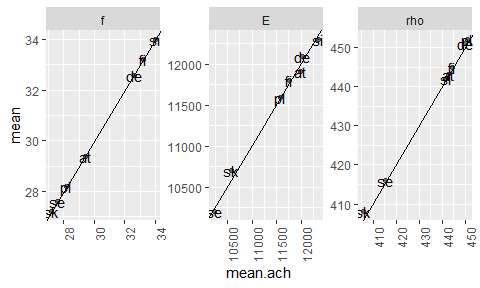

```r
compare_with_def(dataset_c, ssd_c, 'm')
```

Compare achieved coefficients of variation with the defined values. Again, we have undesirable exact values for $f$.

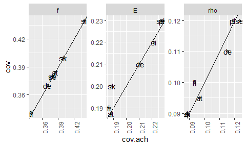

```r
compare_with_def(dataset_c, ssd_c, 'cov')
```

## Different subsample sizes

```r
ssd_cn <- get_subsample_definitions(
  country = c(at = 1, de = 3, fi = 1.5, pl = 2, se = 3, si = 1, sk = 1),
  loadtype = 't'
);

dataset_cn <- simulate_dataset(
  random_seed = 12345,
  n = 5000,
  subsets = ssd_cn
);

summ_fun(dataset_cn);
```

| country | subsample | loadtype | n | f_mean | E_mean | rho_mean | E_dyn_u_mean | ip_f_mean | E_dyn_mean | ip_rho_mean |
| --- | --- | --- | --- | --- | --- | --- | --- | --- | --- | --- |
| at | at | t | 400 | 29.4 (38) | 12189 (19) | 444 (10) | 11320 (18) | 30.1 (30) | 12815 (17) | 460 (9) |
| de | de | t | 1200 | 32.6 (37) | 12102 (21) | 451 (11) | 11302 (19) | 30.2 (33) | 12861 (19) | 464 (11) |
| fi | fi | t | 600 | 33.2 (34) | 11838 (18) | 445 (10) | 11116 (18) | 29.7 (30) | 12600 (17) | 459 (9) |
| pl | pl | t | 800 | 28.2 (38) | 11501 (23) | 451 (12) | 10885 (21) | 27.4 (37) | 12378 (21) | 465 (11) |
| se | se | t | 1200 | 27.6 (38) | 10206 (23) | 417 (12) | 9769 (22) | 23.9 (39) | 10989 (22) | 432 (11) |
| si | si | t | 400 | 34.0 (44) | 12218 (21) | 441 (9) | 11326 (19) | 30.7 (34) | 12801 (19) | 457 (9) |
| sk | sk | t | 400 | 27.2 (40) | 10716 (19) | 407 (9) | 10042 (18) | 26.0 (32) | 11301 (18) | 426 (9) |

|  | f | E | rho | E_dyn_u | ip_f | E_dyn | ip_rho |
| --- | --- | --- | --- | --- | --- | --- | --- |
| **f** | 1 | 0.7386 | 0.3347 | 0.6617 | 0.7733 | 0.68 | 0.3249 |
| **E** | 0.7386 | 1 | 0.6581 | 0.9214 | 0.9231 | 0.9601 | 0.6675 |
| **rho** | 0.3347 | 0.6581 | 1 | 0.6852 | 0.4949 | 0.7485 | 0.9523 |
| **E_dyn_u** | 0.6617 | 0.9214 | 0.6852 | 1 | 0.8715 | 0.9547 | 0.6991 |
| **ip_f** | 0.7733 | 0.9231 | 0.4949 | 0.8715 | 1 | 0.8985 | 0.4798 |
| **E_dyn** | 0.68 | 0.9601 | 0.7485 | 0.9547 | 0.8985 | 1 | 0.7673 |
| **ip_rho** | 0.3249 | 0.6675 | 0.9523 | 0.6991 | 0.4798 | 0.7673 | 1 |

## Own specification of means and standard deviations

In a similar manner to the predefined country specifications, we can also define our own. Since Version 0.6.0, we can also used different sample identifier columns (instead of the standard “country” and “subsample”) – for details, check the help on `simulate_dataset()`.

As an example, we define different properties for boards with different cross sections (width and thickness, given in mm).

```r
ssd_custom <- tibble::tribble(
  ~width, ~thickness, ~f_mean, ~f_sd,
      80,     40,      27.5,    9.0,
     140,     40,      29.4,    9.7,
     160,     60,      31.6,    9.3,
     200,     50,      30.2,   11.4,
     240,     95,      25.5,    4.8,
     250,     40,      25.3,   11.2
);

dataset_custom <- simulate_dataset(
  random_seed = 12345,
  n = 5000,
  subsets = ssd_custom
);

summ_fun(dataset_custom, grp = c('width', 'thickness', 'loadtype'));
```

```
#>
#> ------------------------------------------------------------------------------------------------------------------------------
#>  width   thickness   loadtype    n     f_mean       E_mean     rho_mean   E_dyn_u_mean   ip_f_mean   E_dyn_mean   ip_rho_mean
#> ------- ----------- ---------- ----- ----------- ------------ ---------- -------------- ----------- ------------ -------------
#>   80        40          t       833   27.5 (33)   11647 (16)   439 (9)     10917 (16)    28.4 (27)   12372 (16)     454 (9)
#>
#>   140       40          t       834   29.4 (33)   11939 (17)   443 (9)     11208 (16)    29.6 (27)   12671 (16)     458 (9)
#>
#>   160       60          t       833   31.6 (29)   12329 (15)   447 (9)     11466 (15)    31.0 (23)   13003 (14)     462 (9)
#>
#>   200       50          t       833   30.2 (38)   12052 (17)   444 (9)     11275 (17)    29.9 (28)   12770 (16)     460 (9)
#>
#>   240       95          t       834   25.5 (19)   11601 (14)   442 (9)     10904 (15)    27.8 (23)   12347 (14)     458 (8)
#>
#>   250       40          t       833   25.3 (44)   11155 (20)   434 (9)     10538 (19)    26.1 (36)   11933 (19)     451 (9)
#> ------------------------------------------------------------------------------------------------------------------------------
#>
#>
#> -----------------------------------------------------------------------------
#>    &nbsp;        f        E       rho     E_dyn_u    ip_f    E_dyn    ip_rho
#> ------------- -------- -------- -------- --------- -------- -------- --------
#>     **f**        1      0.6879   0.2889   0.5814    0.7254   0.617    0.2602
#>
#>     **E**      0.6879     1      0.6334    0.885    0.8914   0.9435   0.6329
#>
#>    **rho**     0.2889   0.6334     1       0.639    0.4458   0.7156   0.9301
#>
#>  **E_dyn_u**   0.5814   0.885    0.639       1      0.825    0.931    0.6527
#>
#>   **ip_f**     0.7254   0.8914   0.4458    0.825      1      0.8701   0.4123
#>
#>   **E_dyn**    0.617    0.9435   0.7156    0.931    0.8701     1      0.7361
#>
#>  **ip_rho**    0.2602   0.6329   0.9301   0.6527    0.4123   0.7361     1
#> -----------------------------------------------------------------------------
```

## Further available options

- bending strength simulation
- without log-transform
- from own data using `simbase_covar()`

# Add simulated values to a dataset

For adding simulated values to a dataset, we first need to establish the relationship between these values and some variables in the dataset.

In `WoodSimulatR`, relationships are established in the following way:

1. We determine the covariance matrix and the means of a set of variables, based on some kind of learning dataset. This is done using the function `simbase_covar()`; the resulting *simbase* has class “simbase_covar”.
2. We also have the option to establish different relationships for different subsets of the data, e.g. for different countries of origin. This is done by grouping the dataset accordingly before calling `simbase_covar()`; the resulting *simbase* has class “simbase_list”.

For both these options, it is possible to transform the involved variables.

To visualise the result of the simulation, we use scatterplots and define them in the following function:

```r
plot_sim_gdp <- function(ds, simb, simulated_vars, ...) {
  extra_aes <- rlang::enexprs(...);
  ds <- dplyr::rename(ds, f_ref = f, E_ref = E, rho_ref = rho);
  if (!any(simulated_vars %in% names(ds))) ds <- simulate_conditionally(data = ds, simbase = simb);
  ds <- tidyr::pivot_longer(
    data = ds,
    cols = tidyselect::any_of(c('f_ref', 'E_ref', 'rho_ref', simulated_vars)),
    names_to = c('name', '.value'),
    names_sep = '_'
  );
  ds <- dplyr::mutate(
    ds,
    name = factor(name, levels = c('f', 'E', 'rho'), ordered = TRUE)
  );
  simname <- names(ds);
  simname <- simname[dplyr::cumany(simname == 'name')];
  simname <- setdiff(simname, c('name', 'ref'));
  stopifnot(length(simname) == 1);
  ggplot(data = ds, mapping = aes(.data[[simname]], ref, !!!extra_aes)) +
    geom_point(alpha = .2, shape = 20) +
    geom_abline(slope = 1, intercept = 0, alpha = .5, linetype = 'twodash') +
    facet_wrap(vars(name), scales = 'free') +
    theme(axis.text.x = element_text(angle = 90));
} # undebug(plot_sim_gdp)
```

## `simbase_covar` without transformation

The main approach in `WoodSimulatR` is to conditionally simulate based on the means and the covariance matrix. As a start, we create basis data for the simulation without applying any transformation.

As we later want to add simulated GDP values to a dataset which already contains GDP values, we rename the GDP values for the `simbase_covar` to some other names not yet present in the target dataset, by suffixing with `_siml` (for SIMulation with Linear relationships)

```r
sb_untransf <- dataset_0 %>%
  dplyr::rename(f_siml = f, E_siml = E, rho_siml = rho) %>%
  simbase_covar(
    variables = c('f_siml', 'E_siml', 'rho_siml', 'ip_f', 'E_dyn', 'ip_rho')
  );

sb_untransf;
```

```
#> $label
#> [1] "n5000_t_cov"
#>
#> $variables
#> [1] "f_siml"   "E_siml"   "rho_siml" "ip_f"     "E_dyn"    "ip_rho"
#>
#> $transforms
#> list()
#>
#> $covar
#>               f_siml     E_siml   rho_siml        ip_f      E_dyn     ip_rho
#> f_siml     123.48879   17833.53   176.0599    74.39333   16294.87   157.3809
#> E_siml   17833.52632 5350561.53 60442.9207 19384.22862 4936929.13 60112.9581
#> rho_siml   176.05989   60442.92  2277.8973   165.03216   71523.40  2051.2843
#> ip_f        74.39333   19384.23   165.0322    84.82026   18296.48   154.1760
#> E_dyn    16294.87244 4936929.13 71523.3978 18296.48185 5061578.82 71714.5604
#> ip_rho     157.38089   60112.96  2051.2843   154.17601   71714.56  2083.1286
#>
#> $means
#>      f_siml      E_siml    rho_siml        ip_f       E_dyn      ip_rho
#>    27.44698 10902.33238   426.68168    25.84706 11646.95452   443.01789
#>
#> $loadtype
#> [1] "t"
#>
#> attr(,"class")
#> [1] "simbase_covar"
```

Adding the simulated GDP values to a dataset is done by calling `simulate_conditionally()`.

```r
dataset_c_sim <- simulate_conditionally(dataset_c, sb_untransf);
names(dataset_c_sim) %>% pander::pander();
```

*subsample*, *country*, *f*, *E*, *rho*, *E_dyn_u*, *ip_f*, *E_dyn*, *ip_rho*, *loadtype*, *f_siml*, *E_siml* and *rho_siml*

For a visual comparison:

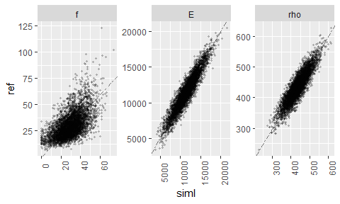

```r
plot_sim_gdp(dataset_c_sim, sb_untransf, c('f_siml', 'E_siml', 'rho_siml'));
```

This looks good for $E$ and $\rho$, but wrong in the $f$ simulation.

## `simbase_covar` with log-transformed $f$

We might try using `transforms` to improve the result. For this, we have to pass a list with named entries corresponding to the GDP we want to transform.

The entry itself must be an object of class `"trans"` (from the package `scales`, version < 1.3.0) or class `"transform"` (package `scales`, version $\ge$ 1.3.0). As we want to use a log-transform, the required entry is `scales::log_trans()`.

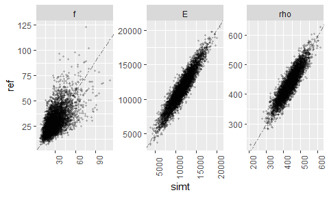

```r
sb_transf <- dataset_0 %>%
  dplyr::rename(f_simt = f, E_simt = E, rho_simt = rho) %>%
  simbase_covar(
    variables = c('f_simt', 'E_simt', 'rho_simt', 'ip_f', 'E_dyn', 'ip_rho'),
    transforms = list(f_simt = scales::log_trans())
  );
dataset_c_sim <- simulate_conditionally(dataset_c_sim, sb_transf);
plot_sim_gdp(dataset_c_sim, sb_transf, c('f_simt', 'E_simt', 'rho_simt'));
```

Now, this looks much better (which is no surprise, as `dataset_c` itself has been simulated with lognormal $f$).

## `simbase_covar` with log-transformed $f$ and derived on a grouped dataset

If we group the reference dataset (`dataset_0`), e.g. by country, we get an object of class “simbase_list” with separate simbases for each group (technically, this is a `tibble` with the grouping variables and an extra column `.simbase` which contains several objects of class “simbase_covar”).

```r
sb_group <- dataset_0 %>%
  dplyr::group_by(country) %>%
  dplyr::rename(f_simg = f, E_simg = E, rho_simg = rho) %>%
  simbase_covar(
    variables = c('f_simg', 'E_simg', 'rho_simg', 'ip_f', 'E_dyn', 'ip_rho'),
    transforms = list(f_simg = scales::log_trans())
  );

sb_group
```

```
#> # A tibble: 4 × 2
#>   country .simbase
#>   <chr>   <list>
#> 1 C1      <smbs_cvr>
#> 2 C2      <smbs_cvr>
#> 3 C3      <smbs_cvr>
#> 4 C4      <smbs_cvr>
```

If we add variables to a dataset using such a “simbase_list”, it is required that all grouping variables stored in the “simbase_list” object are also available in this dataset.

In our case: the dataset must contain the variable “country”. Values of “country” which do not also exist in our “simbase” object will result in `NA` values for the variables to be simulated.

Therefore, we add the variables in this case not to the dataset `dataset_c` (which has different values for “country”) but to the `dataset_0` itself.

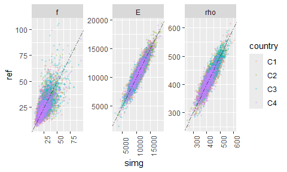

```r
dataset_0_sim <- simulate_conditionally(dataset_0, sb_group);
plot_sim_gdp(dataset_0_sim, sb_group, c('f_simg', 'E_simg', 'rho_simg'), colour=country);
```

# Simulate a whole dataset, based on a `simbase_list` object

Simbase objects of class “simbase_list” can also be used for simulating an entire dataset, as long as the “simbase_list” only has the grouping variable(s) “country” and/or “subsample”, and as long as the value combinations in “country”/“subsample” match those given in the “subsets” argument to the function `simulate_dataset`.

To demonstrate, we calculate a “simbase_list” based on the `dataset_c` created above. Here, we *do not rename* any of the variables.

```r
sb_group_c <- dataset_c %>%
  dplyr::group_by(country) %>%
  simbase_covar(
    variables = c('f', 'E', 'rho', 'ip_f', 'E_dyn', 'ip_rho'),
    transforms = list(f = scales::log_trans())
  );

sb_group_c
```

```
#> # A tibble: 7 × 2
#>   country .simbase
#>   <chr>   <list>
#> 1 at      <smbs_cvr>
#> 2 de      <smbs_cvr>
#> 3 fi      <smbs_cvr>
#> 4 pl      <smbs_cvr>
#> 5 se      <smbs_cvr>
#> 6 si      <smbs_cvr>
#> 7 sk      <smbs_cvr>
```

This “simbase_list” is now used as input to `simulate_dataset` with the subset definitions used previously (`ssd_cn`).

```r
dataset_cn2 <- simulate_dataset(
  random_seed = 12345,
  n = 5000,
  subsets = ssd_cn,
  simbase = sb_group_c
);

summ_fun(dataset_cn2);
```

| country | subsample | loadtype | n | f_mean | E_mean | rho_mean | ip_f_mean | E_dyn_mean | ip_rho_mean |
| --- | --- | --- | --- | --- | --- | --- | --- | --- | --- |
| at | at | t | 400 | 29.4 (38) | 12190 (19) | 444 (10) | 29.9 (30) | 12844 (17) | 460 (9) |
| de | de | t | 1200 | 32.6 (37) | 12122 (20) | 450 (11) | 30.2 (31) | 12891 (19) | 465 (11) |
| fi | fi | t | 600 | 33.2 (34) | 11903 (19) | 445 (10) | 29.7 (29) | 12698 (18) | 459 (10) |
| pl | pl | t | 800 | 28.2 (38) | 11620 (24) | 451 (12) | 27.8 (39) | 12459 (22) | 465 (11) |
| se | se | t | 1200 | 27.6 (38) | 10196 (22) | 417 (12) | 23.9 (37) | 10983 (20) | 433 (11) |
| si | si | t | 400 | 34.0 (44) | 12466 (22) | 442 (9) | 31.6 (34) | 13100 (19) | 460 (8) |
| sk | sk | t | 400 | 27.2 (40) | 10563 (21) | 406 (9) | 25.5 (36) | 11245 (19) | 426 (9) |

|  | f | E | rho | ip_f | E_dyn | ip_rho |
| --- | --- | --- | --- | --- | --- | --- |
| **f** | 1 | 0.7467 | 0.3238 | 0.7827 | 0.6814 | 0.3103 |
| **E** | 0.7467 | 1 | 0.6582 | 0.9221 | 0.9601 | 0.6651 |
| **rho** | 0.3238 | 0.6582 | 1 | 0.4939 | 0.7474 | 0.9515 |
| **ip_f** | 0.7827 | 0.9221 | 0.4939 | 1 | 0.8992 | 0.4804 |
| **E_dyn** | 0.6814 | 0.9601 | 0.7474 | 0.8992 | 1 | 0.767 |
| **ip_rho** | 0.3103 | 0.6651 | 0.9515 | 0.4804 | 0.767 | 1 |

# Conclusions

The package `WoodSimulatR` has functions for simulating entire datasets of sawn timber properties, both based on internal definitions and on externally supplied base data.

`WoodSimulatR` also has functions for adding simulated grade determining properties (or other properties) to a given dataset, based on a covariance matrix approach.

The functions for adding simulated variables are suitable for all kinds of datasets, if one calculates an appropriate `simbase_covar` object oneself, by a call to `simbase_covar` using reference data.

The simulation methods also support variable transformations to accommodate non-normally distributed variables.

# References

Ranta-Maunus, Alpo, Julia K. Denzler, and Peter Stapel. 2011. *Strength of European Timber. Part 2. Properties of Spruce and Pine Tested in Gradewood Project.* VTT.

Rohanová, Alena, and Erika Nunez. 2014. “Prediction Models of Slovakian Structural Timber.” *Wood Research* 59 (5): 757–69.

Stapel, Peter, and Jan-Willem G. van de Kuilen. 2014. “Efficiency of Visual Strength Grading of Timber with Respect to Origin, Species, Cross Section, and Grading Rules: A Critical Evaluation of the Common Standards.” *Holzforschung* 68 (2): 203–16.